# Analise

```python
import numpy as np
import pandas as pd
import matplotlib.pyplot as plt
import seaborn as sns
```

#### Análise exploratória para o ano de 2006

```python
dataset2006 = pd.read_excel('./data/Vigitel-2006-peso-rake.xls')
```

```python
dataset2006.head()
```

|  | ordem | ano | cidade | replica | q6 | q7 | civil | q8a | q8b | anoescol | ... | ati_l | ativo_livre | ativo_livre_trans | ina_livre | inat_des_trab | inat_des_esc | inat_desl | atilaz_trans | tv_d_3 | pesorake |
| --- | --- | --- | --- | --- | --- | --- | --- | --- | --- | --- | --- | --- | --- | --- | --- | --- | --- | --- | --- | --- | --- |
| 0 | 1 | 2006 | 7 | 1 | 37 | 2 | 2 | 3.0 | 8.0 | 8.0 | ... | NaN | NaN | NaN | 1 | NaN | NaN | NaN | NaN | 1 | 586.95599 |
| 1 | 2 | 2006 | 27 | 1 | 40 | 2 | 2 | 4.0 | 3.0 | 11.0 | ... | NaN | NaN | NaN | 1 | NaN | NaN | NaN | NaN | 1 | 615.21655 |
| 2 | 3 | 2006 | 10 | 2 | 64 | 2 | 2 | 3.0 | 5.0 | 5.0 | ... | NaN | NaN | NaN | 0 | NaN | NaN | NaN | NaN | 0 | 593.09100 |
| 3 | 4 | 2006 | 8 | 1 | 49 | 1 | 4 | 7.0 | 3.0 | 14.0 | ... | NaN | NaN | NaN | 0 | NaN | NaN | NaN | NaN | 0 | 139.26321 |
| 4 | 5 | 2006 | 7 | 1 | 29 | 2 | 1 | 7.0 | 7.0 | 18.0 | ... | NaN | NaN | NaN | 0 | NaN | NaN | NaN | NaN | 0 | 565.91864 |

5 rows × 155 columns

```python
# mostra a quantidade de linhas e os typos dos dados contidos nas colunas
dataset2006.info()
```

```
<class 'pandas.core.frame.DataFrame'>
RangeIndex: 54369 entries, 0 to 54368
Columns: 155 entries, ordem to pesorake
dtypes: float64(88), int64(67)
memory usage: 64.3 MB
```

```python
# estatísticas básicas para variáveis numéricas do data frame

dataset2006.describe()
```

|  | ordem | ano | cidade | replica | q6 | q7 | civil | q8a | q8b | anoescol | ... | ati_l | ativo_livre | ativo_livre_trans | ina_livre | inat_des_trab | inat_des_esc | inat_desl | atilaz_trans | tv_d_3 | pesorake |
| --- | --- | --- | --- | --- | --- | --- | --- | --- | --- | --- | --- | --- | --- | --- | --- | --- | --- | --- | --- | --- | --- |
| count | 54369.00000 | 54369.000000 | 54369.000000 | 54369.000000 | 54369.000000 | 54369.000000 | 54369.000000 | 54023.000000 | 52589.000000 | 53973.000000 | ... | 0.0 | 0.0 | 0.0 | 54369.000000 | 0.0 | 0.0 | 0.0 | 0.0 | 54369.000000 | 54369.000000 |
| mean | 27185.00000 | 2006.028932 | 13.990049 | 16.214221 | 42.118413 | 1.608343 | 1.910022 | 4.563945 | 3.630968 | 10.140904 | ... | NaN | NaN | NaN | 0.527580 | NaN | NaN | NaN | NaN | 0.270283 | 552.634627 |
| std | 15695.12273 | 0.167617 | 7.791249 | 13.377647 | 16.469083 | 0.488125 | 0.849729 | 2.159699 | 1.813525 | 4.472371 | ... | NaN | NaN | NaN | 0.499243 | NaN | NaN | NaN | NaN | 0.444110 | 986.915932 |
| min | 1.00000 | 2006.000000 | 1.000000 | 1.000000 | 18.000000 | 1.000000 | 1.000000 | 1.000000 | 1.000000 | 0.000000 | ... | NaN | NaN | NaN | 0.000000 | NaN | NaN | NaN | NaN | 0.000000 | 3.095822 |
| 25% | 13593.00000 | 2006.000000 | 7.000000 | 6.000000 | 29.000000 | 1.000000 | 1.000000 | 3.000000 | 3.000000 | 8.000000 | ... | NaN | NaN | NaN | 0.000000 | NaN | NaN | NaN | NaN | 0.000000 | 108.107450 |
| 50% | 27185.00000 | 2006.000000 | 14.000000 | 12.000000 | 40.000000 | 2.000000 | 2.000000 | 4.000000 | 3.000000 | 11.000000 | ... | NaN | NaN | NaN | 1.000000 | NaN | NaN | NaN | NaN | 0.000000 | 244.009050 |
| 75% | 40777.00000 | 2006.000000 | 21.000000 | 19.000000 | 53.000000 | 2.000000 | 2.000000 | 7.000000 | 4.000000 | 13.000000 | ... | NaN | NaN | NaN | 1.000000 | NaN | NaN | NaN | NaN | 1.000000 | 565.043460 |
| max | 54369.00000 | 2007.000000 | 27.000000 | 47.000000 | 101.000000 | 2.000000 | 4.000000 | 10.000000 | 8.000000 | 18.000000 | ... | NaN | NaN | NaN | 1.000000 | NaN | NaN | NaN | NaN | 1.000000 | 20668.465000 |

8 rows × 155 columns

```python
dataset2006.columns[0:50]
```

```
Index(['ordem', 'ano', 'cidade', 'replica', 'q6', 'q7', 'civil', 'q8a', 'q8b',
       'anoescol', 'q9', 'q10', 'q11', 'q12', 'q13', 'q14', 'q14a', 'q15',
       'q17', 'q18', 'q19', 'q20', 'q21a', 'q22', 'q23a', 'q24', 'q27', 'q28',
       'q29', 'q30', 'q31', 'q32a', 'q33', 'q35', 'q36', 'q37a', 'q37b',
       'q38a', 'q38b', 'q41', 'q42', 'q43', 'q43a', 'q44', 'q45', 'q46', 'q47',
       'q48', 'q49', 'q50'],
      dtype='object')
```

```python
dataset2006.columns[50:100]
```

```
Index(['q51', 'q55', 'q55a', 'q56', 'q57', 'q58', 'q59', 'q60', 'q61', 'q62',
       'q63', 'q64', 'q65', 'q66', 'q69', 'q70', 'q71', 'q73', 'q74', 'q75',
       'q76', 'q77', 'q78', 'q85', 'q86', 'q87', 'morador', 'adultos', 'r101',
       'r102', 'r103', 'r104', 'r105', 'r106', 'pinterno', 'fet', 'cat_esc',
       'anoescmi', 'fesc', 'catcenso', 'razao', 'amostra', 'pesofim',
       'fumante', 'mais20', 'iddfuma', 'exfuma', 'iddexfu', 'imc', 'excpeso'],
      dtype='object')
```

```python
dataset2006.columns[100:155]
```

```
Index(['obesid', 'hortareg', 'frutareg', 'flvreg', 'cruadia', 'cozidadi',
       'hortadia', 'sofrutad', 'frutadia', 'flvdia', 'flvreco', 'carneg',
       'franpl', 'gordura', 'leiteint', 'refri5', 'atilaz', 'atiocu',
       'atitrans', 'atidom', 'inativo', 'alcabu', 'saruim', 'hart', 'diab',
       'coracao', 'dislipi', 'osteo', 'pesofim1', 'peso_miss', 'q8_anos',
       'regra_altura', 'q9_i', 'altura_miss', 'regra_peso', 'q11_i', 'imc_i',
       'excpeso_i', 'obesid_i', 'refritl5', 'feijao5', 'af', 'freq', 'time',
       'ati_livre', 'ati_l', 'ativo_livre', 'ativo_livre_trans', 'ina_livre',
       'inat_des_trab', 'inat_des_esc', 'inat_desl', 'atilaz_trans', 'tv_d_3',
       'pesorake'],
      dtype='object')
```

## Identificação de Variáveis Relevantes

- Com base nas colunas listadas, podemos fazer as seguintes associações com as questões formuladas:

#### Sintomas de HA:

- hart (Hipertensão arterial)

#### Fatores Comportamentais:

- Obesidade: imc, excpeso, obesid
- Tabagismo: fumante, exfuma
- Álcool: alcabu
- Sedentarismo: inativo, ati_livre

#### Hábitos Saudáveis:

- Atividades físicas: atilaz, atiocu, atitrans, atidom
- Alimentação: hortareg, frutareg, flvreg, cruadia, cozidadi, hortadia, sofrutad, frutadia, flvdia, flvreco, carneg, franpl, gordura, leiteint, refri5, feijao5

#### Modalidades de Atividades Físicas:

- Especificação de atividades: atilaz, atiocu, atitrans, atidom, ati_livre, ativo_livre, ativo_livre_trans

#### Uso de Mídias Digitais:

- tv_d_3 (Assistir TV mais de 3 horas por dia)

#### Analisando a prevalência de hipertensão arterial (hart)

Vamos verificar a distribuição de hart para identificar a prevalência de hipertensão arterial em 2006.

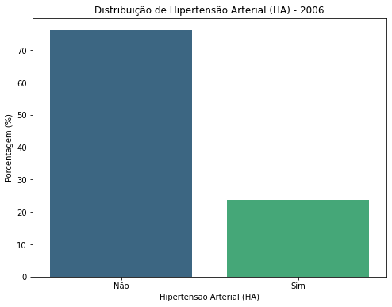

```
0    76.173923
1    23.826077
Name: hart, dtype: float64
```

```python
import matplotlib.pyplot as plt
import seaborn as sns

hart_distribution = dataset2006['hart'].value_counts(normalize=True)
hart_distribution_percentage = hart_distribution * 100

plt.figure(figsize=(8, 6))
sns.barplot(x=hart_distribution_percentage.index, y=hart_distribution_percentage.values, palette='viridis')
plt.title('Distribuição de Hipertensão Arterial (HA) - 2006')
plt.xlabel('Hipertensão Arterial (HA)')
plt.ylabel('Porcentagem (%)')
plt.xticks([0, 1], ['Não', 'Sim'])
plt.show()

hart_distribution_percentage
```

A distribuição da prevalência de hipertensão arterial em 2006 é a seguinte:

Não: 76.17%

Sim: 23.83%

#### Investigando fatores comportamentais

Vamos agora investigar a relação entre a hipertensão arterial (hart) e os fatores comportamentais: obesidade, tabagismo, álcool e sedentarismo.

Para isso, vamos calcular a prevalência de HA entre os diferentes grupos definidos por esses fatores.

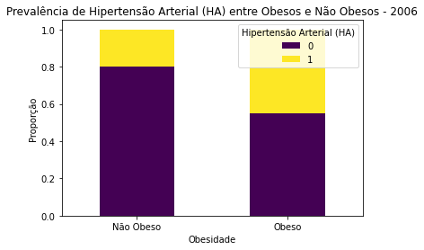

```python
obesity_ha_distribution = dataset2006.groupby('obesid')['hart'].value_counts(normalize=True).unstack()

plt.figure(figsize=(10, 6))
obesity_ha_distribution.plot(kind='bar', stacked=True, colormap='viridis')
plt.title('Prevalência de Hipertensão Arterial (HA) entre Obesos e Não Obesos - 2006')
plt.xlabel('Obesidade')
plt.ylabel('Proporção')
plt.legend(title='Hipertensão Arterial (HA)', loc='best')
plt.xticks(ticks=[0, 1], labels=['Não Obeso', 'Obeso'], rotation=0)
plt.show()
```

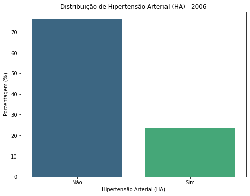

```
0    76.173923
1    23.826077
Name: hart, dtype: float64
```

```python
hart_distribution = dataset2006['hart'].value_counts(normalize=True)
hart_distribution_percentage = hart_distribution * 100

plt.figure(figsize=(8, 6))
sns.barplot(x=hart_distribution_percentage.index, y=hart_distribution_percentage.values, palette='viridis')
plt.title('Distribuição de Hipertensão Arterial (HA) - 2006')
plt.xlabel('Hipertensão Arterial (HA)')
plt.ylabel('Porcentagem (%)')
plt.xticks([0, 1], ['Não', 'Sim'])
plt.show()

hart_distribution_percentage
```

A análise mostra a proporção de hipertensão arterial entre indivíduos obesos e não obesos em 2006. Observa-se que a prevalência de HA é maior entre os obesos.

#### Hábitos Saudáveis

Vamos investigar se adotar hábitos saudáveis como a prática de atividades físicas e uma alimentação equilibrada contribuem positivamente para reduzir a HA.

[figure not shown]

```python
dactivity_laz_ha_distribution = dataset.groupby('atilaz')['hart'].value_counts(normalize=True).unstack()

plt.figure(figsize=(10, 6))
activity_laz_ha_distribution.plot(kind='bar', stacked=True, colormap='viridis')
plt.title('Prevalência de Hipertensão Arterial (HA) entre Praticantes e Não Praticantes de Atividades Físicas no Lazer - 2006')
plt.xlabel('Prática de Atividades Físicas no Lazer')
plt.ylabel('Proporção')
plt.legend(title='Hipertensão Arterial (HA)', loc='best')
plt.xticks(ticks=[0, 1], labels=['Não Pratica', 'Pratica'], rotation=0)
plt.show()
```

A análise mostra a proporção de hipertensão arterial entre indivíduos que praticam e não praticam atividades físicas no lazer em 2006. Observa-se que a prevalência de HA é menor entre aqueles que praticam atividades físicas no lazer.

#### Modalidades de Atividades Físicas

Para analisar se praticar determinadas modalidades de atividades físicas e com frequência mínima recomendada contribuem positivamente para reduzir a HA, vamos explorar as variáveis relacionadas a diferentes tipos de atividades físicas e sua frequência. Variáveis como atiocu (atividade física ocupacional), atitrans (atividade física de transporte), e atidom (atividade física doméstica) podem ser relevantes.

Vamos verificar a relação entre hipertensão arterial e a prática de atividades físicas ocupacionais.

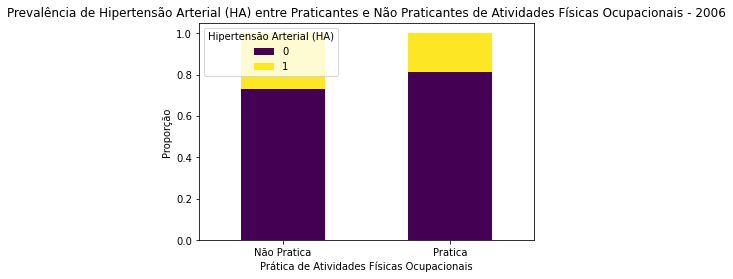

```python
activity_ocu_ha_distribution = dataset2006.groupby('atiocu')['hart'].value_counts(normalize=True).unstack()

plt.figure(figsize=(10, 6))
activity_ocu_ha_distribution.plot(kind='bar', stacked=True, colormap='viridis')
plt.title('Prevalência de Hipertensão Arterial (HA) entre Praticantes e Não Praticantes de Atividades Físicas Ocupacionais - 2006')
plt.xlabel('Prática de Atividades Físicas Ocupacionais')
plt.ylabel('Proporção')
plt.legend(title='Hipertensão Arterial (HA)', loc='best')
plt.xticks(ticks=[0, 1], labels=['Não Pratica', 'Pratica'], rotation=0)
plt.show()
```

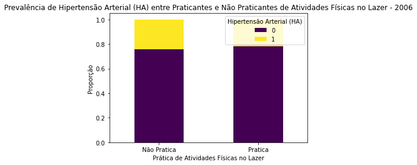

```python
activity_laz_ha_distribution = dataset2006.groupby('atilaz')['hart'].value_counts(normalize=True).unstack()

plt.figure(figsize=(10, 6))
activity_laz_ha_distribution.plot(kind='bar', stacked=True, colormap='viridis')
plt.title('Prevalência de Hipertensão Arterial (HA) entre Praticantes e Não Praticantes de Atividades Físicas no Lazer - 2006')
plt.xlabel('Prática de Atividades Físicas no Lazer')
plt.ylabel('Proporção')
plt.legend(title='Hipertensão Arterial (HA)', loc='best')
plt.xticks(ticks=[0, 1], labels=['Não Pratica', 'Pratica'], rotation=0)
plt.show()
```

A análise mostra a proporção de hipertensão arterial entre indivíduos que praticam e não praticam atividades físicas ocupacionais em 2006. Observa-se que a prevalência de HA é menor entre aqueles que praticam atividades físicas ocupacionais.

#### Uso de Mídias Digitais

Para analisar se o uso frequente e prolongado de mídias digitais amplia a percepção de um aumento no número de casos de HA, vamos utilizar a variável tv_d_3 (Assistir TV mais de 3 horas por dia).

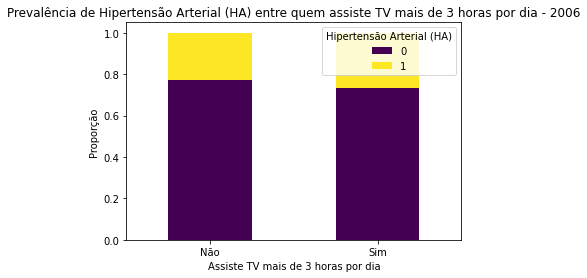

```python
tv_ha_distribution = dataset2006.groupby('tv_d_3')['hart'].value_counts(normalize=True).unstack()

plt.figure(figsize=(10, 6))
tv_ha_distribution.plot(kind='bar', stacked=True, colormap='viridis')
plt.title('Prevalência de Hipertensão Arterial (HA) entre quem assiste TV mais de 3 horas por dia - 2006')
plt.xlabel('Assiste TV mais de 3 horas por dia')
plt.ylabel('Proporção')
plt.legend(title='Hipertensão Arterial (HA)', loc='best')
plt.xticks(ticks=[0, 1], labels=['Não', 'Sim'], rotation=0)
plt.show()
```

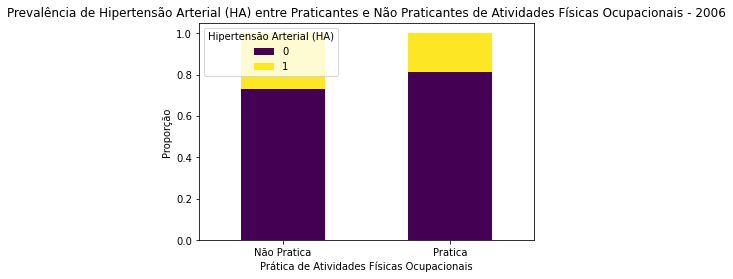

```python
activity_ocu_ha_distribution = dataset2006.groupby('atiocu')['hart'].value_counts(normalize=True).unstack()

plt.figure(figsize=(10, 6))
activity_ocu_ha_distribution.plot(kind='bar', stacked=True, colormap='viridis')
plt.title('Prevalência de Hipertensão Arterial (HA) entre Praticantes e Não Praticantes de Atividades Físicas Ocupacionais - 2006')
plt.xlabel('Prática de Atividades Físicas Ocupacionais')
plt.ylabel('Proporção')
plt.legend(title='Hipertensão Arterial (HA)', loc='best')
plt.xticks(ticks=[0, 1], labels=['Não Pratica', 'Pratica'], rotation=0)
plt.show()
```

##### As mesmas análises se aplicam a demais anos

Então seguiremos para uma análise para o ano de 2023 para que possamos contrapor aos dados de coleta iniciais de 2006

Dessa vez podemos tentar uma abordagem de visualização diferente dos dados com o objetivo de ter maior diversidade formas de apresentação de resultados

Vamos para isso usar uma matriz de correlação. Lembrando que valores próximos de 1 ou -1 indicam uma correlação forte, enquanto valores próximos de 0 indicam pouca ou nenhuma correlação.

```python
dataset2023 = pd.read_excel('./data/Vigitel-2023-peso-rake.xlsx')
```

```python
dataset2023.head() # existem diferenças nas nomenclaturas das colunas
```

|  | chave | tipo_fone | replica | cidade | ano | q6 | q7 | q8a | q8b | q9 | ... | depressao | ind_med_has | med_has | trat_med_has | ind_med_db | med_db | insulina | trat_med_db | ind_med_depr | trat_med_depr |
| --- | --- | --- | --- | --- | --- | --- | --- | --- | --- | --- | --- | --- | --- | --- | --- | --- | --- | --- | --- | --- | --- |
| 0 | 159775260937 | CELULAR | 12 | 5 | 2023 | 18 | 1 | 5 | 2.0 | 62 | ... | 0 | NaN | NaN | NaN | NaN | NaN | NaN | NaN | NaN | NaN |
| 1 | 459610290826 | CELULAR | 18 | 12 | 2023 | 23 | 1 | 5 | 2.0 | 96 | ... | 0 | NaN | NaN | NaN | NaN | NaN | NaN | NaN | NaN | NaN |
| 2 | 439521590847 | CELULAR | 5 | 4 | 2023 | 32 | 1 | 4 | 8.0 | 93 | ... | 0 | NaN | NaN | NaN | NaN | NaN | NaN | NaN | NaN | NaN |
| 3 | 119768260943 | CELULAR | 15 | 5 | 2023 | 38 | 1 | 8 | NaN | 777 | ... | 0 | NaN | NaN | NaN | NaN | NaN | NaN | NaN | NaN | NaN |
| 4 | 349242860840 | CELULAR | 17 | 10 | 2023 | 42 | 1 | 4 | 8.0 | 89 | ... | 0 | NaN | NaN | NaN | NaN | NaN | NaN | NaN | NaN | NaN |

5 rows × 233 columns

```python
dataset2023.info() #233 entries na coleta mais recente
```

```
<class 'pandas.core.frame.DataFrame'>
RangeIndex: 21690 entries, 0 to 21689
Columns: 233 entries, chave to trat_med_depr
dtypes: float64(113), int64(114), object(6)
memory usage: 38.6+ MB
```

```python
dataset2023.describe()
```

|  | chave | replica | cidade | ano | q6 | q7 | q8a | q8b | q9 | q11 | ... | depressao | ind_med_has | med_has | trat_med_has | ind_med_db | med_db | insulina | trat_med_db | ind_med_depr | trat_med_depr |
| --- | --- | --- | --- | --- | --- | --- | --- | --- | --- | --- | --- | --- | --- | --- | --- | --- | --- | --- | --- | --- | --- |
| count | 2.169000e+04 | 21690.000000 | 21690.000000 | 21690.0 | 21690.000000 | 21690.000000 | 21690.000000 | 21272.000000 | 21690.000000 | 21690.000000 | ... | 21690.000000 | 7405.000000 | 7405.000000 | 7405.000000 | 2826.000000 | 2826.000000 | 2826.000000 | 2826.000000 | 2972.000000 | 2972.000000 |
| mean | 2.841828e+11 | 19.667404 | 14.003181 | 2023.0 | 49.669617 | 1.625081 | 9.266943 | 3.596183 | 99.951683 | 197.024620 | ... | 0.137022 | 0.924105 | 0.845375 | 0.840918 | 0.911890 | 0.819179 | 0.199575 | 0.857042 | 0.861709 | 0.495626 |
| std | 3.225600e+11 | 22.188005 | 7.798268 | 0.0 | 17.827901 | 0.484113 | 59.051148 | 1.881862 | 136.367189 | 138.043489 | ... | 0.343878 | 0.264847 | 0.361571 | 0.365777 | 0.283506 | 0.384938 | 0.399752 | 0.350092 | 0.345263 | 0.500065 |
| min | 2.104521e+08 | 1.000000 | 1.000000 | 2023.0 | 18.000000 | 1.000000 | 1.000000 | 1.000000 | 30.000000 | 120.000000 | ... | 0.000000 | 0.000000 | 0.000000 | 0.000000 | 0.000000 | 0.000000 | 0.000000 | 0.000000 | 0.000000 | 0.000000 |
| 25% | 3.137964e+10 | 5.000000 | 7.000000 | 2023.0 | 35.000000 | 1.000000 | 5.000000 | 3.000000 | 62.000000 | 158.000000 | ... | 0.000000 | 1.000000 | 1.000000 | 1.000000 | 1.000000 | 1.000000 | 0.000000 | 1.000000 | 1.000000 | 0.000000 |
| 50% | 9.635723e+10 | 12.000000 | 14.000000 | 2023.0 | 49.000000 | 2.000000 | 5.000000 | 3.000000 | 72.000000 | 165.000000 | ... | 0.000000 | 1.000000 | 1.000000 | 1.000000 | 1.000000 | 1.000000 | 0.000000 | 1.000000 | 1.000000 | 0.000000 |
| 75% | 4.991124e+11 | 27.000000 | 21.000000 | 2023.0 | 64.000000 | 2.000000 | 6.000000 | 4.000000 | 84.000000 | 173.000000 | ... | 0.000000 | 1.000000 | 1.000000 | 1.000000 | 1.000000 | 1.000000 | 0.000000 | 1.000000 | 1.000000 | 1.000000 |
| max | 9.999939e+11 | 157.000000 | 27.000000 | 2023.0 | 109.000000 | 2.000000 | 888.000000 | 8.000000 | 888.000000 | 888.000000 | ... | 1.000000 | 1.000000 | 1.000000 | 1.000000 | 1.000000 | 1.000000 | 1.000000 | 1.000000 | 1.000000 | 1.000000 |

8 rows × 227 columns

```python
dataset2023.columns[0:50]
```

```
Index(['chave', 'tipo_fone', 'replica', 'cidade', 'ano', 'q6', 'q7', 'q8a',
       'q8b', 'q9', 'q11', 'q12', 'q13', 'q14', 'r190', 'r128a', 'q15', 'q16',
       'q17', 'q18', 'q19', 'q20', 'q25', 'q26', 'q27', 'q28', 'q29', 'q30',
       'q31', 'r301_a', 'r301_b', 'r301_c', 'r301_d', 'r301_e', 'r301_f',
       'r301_g', 'r301_h', 'r301_i', 'r301_j', 'r301_k', 'r301_l', 'r302_a',
       'r302_b', 'r302_c', 'r302_d', 'r302_e', 'r302_f', 'r302_g', 'r302_h',
       'r302_i'],
      dtype='object')
```

```python
dataset2023.columns[50:100]
```

```
Index(['r302_j', 'r302_k', 'r302_l', 'r302_m', 'q35', 'q36', 'q37', 'q38',
       'q40', 'q40b', 'q42', 'q43a', 'q43a_ou', 'q44', 'q45', 'q46', 'q47',
       'q48', 'q49', 'r147', 'r148_hh', 'r148_mm', 'q50', 'q51', 'q52', 'q53',
       'q54', 'q55', 'q56', 'r149', 'r150_hh', 'r150_mm', 'q59a', 'q59b',
       'q59c', 'q60', 'q61', 'q61_fx', 'q64', 'q67', 'q68', 'r157', 'r401',
       'r401a_1', 'r401b_1', 'r401b_2', 'r401c_1', 'r401c_2', 'r401c_3',
       'r402'],
      dtype='object')
```

```python
dataset2023.columns[100:150]
```

```
Index(['r404', 'r404_ou', 'r403', 'q74', 'q75', 'r203', 'r129', 'q76', 'r204',
       'r133a', 'r133b', 'r205', 'r206', 'r207', 'q79a', 'q80', 'q81', 'q82',
       'r501', 'r502', 'r503', 'r504', 'r505_1', 'r505_2', 'r505_3', 'r505_4',
       'r505_5', 'r505_90', 'r505_ou', 'r506', 'r506_ou', 'q88', 'q69',
       'q69_ou', 'civil', 'q70', 'q71', 'r135', 'r178', 'moradores', 'adultos',
       'fet', 'q8_anos', 'fesc', 'pinterno', 'pesorake', 'pesorake_fixo',
       'pesorake_celular', 'q9_i', 'q11_i'],
      dtype='object')
```

```python
dataset2023.columns[150:233]
```

```
Index(['fumante', 'exfuma', 'mais20', 'eletronico', 'fumocasa', 'fumotrab',
       'imc', 'imc_i', 'excpeso', 'excpeso_i', 'obesid', 'obesid_i',
       'hortareg', 'frutareg', 'flvreg', 'cruadia', 'cozidadia', 'hortadia',
       'sucodia', 'sofrutadia', 'frutadia', 'flvdia', 'flvreco', 'refritl5',
       'feijao5', 'score_sf', 'score_sf_2cat', 'score_upp', 'score_upp_2cat',
       'af', 'freq', 'time', 'ati_livre', 'ativo_livre', 'atitrans', 'atidom',
       'atiocu', 'inativo', 'q51medio', 'q54medio', 'deslocdia',
       'deslocsemana', 'atiocusemana', 'faxinasemana', 'af3dominios',
       'af3dominios_insu', 'tv_d_3', 'tempo_tela_stv', 'q59a_horas',
       'q59c_horas', 'tempo_tela_total', 'time_2023', 'ati_livre_2023',
       'inativo_2023', 'q51medio_2023', 'q54medio_2023', 'deslocdia_2023',
       'deslocsemana_2023', 'af3dominios_2023', 'af3dominios_insu_2023',
       'alcabu', 'direcao', 'direcao_alc', 'saruim', 'iddmamo', 'mamo',
       'mamodois', 'iddpapa_old', 'iddpapa', 'papa', 'papatres', 'hart',
       'diab', 'depressao', 'ind_med_has', 'med_has', 'trat_med_has',
       'ind_med_db', 'med_db', 'insulina', 'trat_med_db', 'ind_med_depr',
       'trat_med_depr'],
      dtype='object')
```

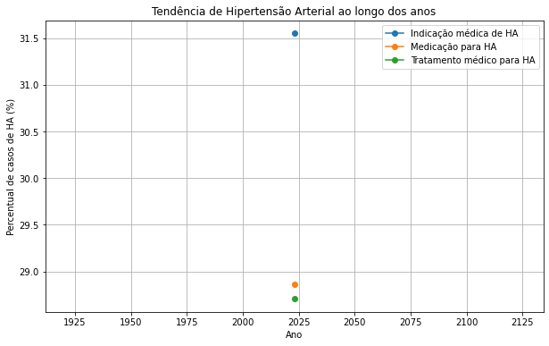

```python
ha_columns = ['ano', 'ind_med_has', 'med_has', 'trat_med_has']
ha_data = dataset2023[ha_columns]
ha_trend = ha_data.groupby('ano').sum()
ha_trend_percentage = ha_trend.div(ha_data.groupby('ano').size(), axis=0) * 100

plt.figure(figsize=(10, 6))
plt.plot(ha_trend_percentage, marker='o')
plt.title('Tendência de Hipertensão Arterial ao longo dos anos')
plt.xlabel('Ano')
plt.ylabel('Percentual de casos de HA (%)')
plt.legend(['Indicação médica de HA', 'Medicação para HA', 'Tratamento médico para HA'])
plt.grid(True)
plt.show()
```

```python
#### Investigar se a obesidade, o tabagismo, o álcool e o sedentarismo são fatores que indicam um aumento da propensão de pessoas com HA
```

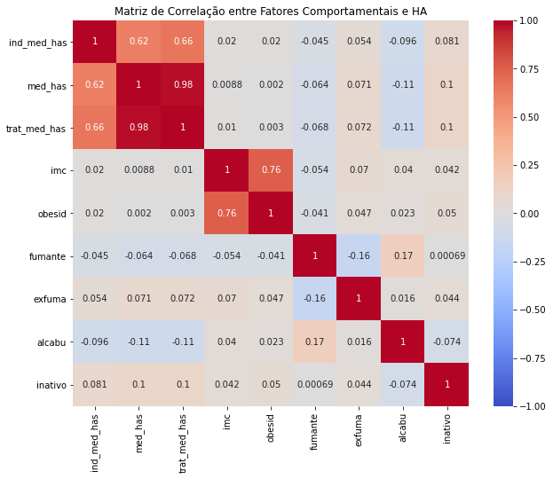

```python
behavior_columns = ['ind_med_has', 'med_has', 'trat_med_has', 'imc', 'obesid', 'fumante', 'exfuma', 'alcabu', 'inativo']
behavior_data = dataset2023[behavior_columns]

correlations = behavior_data.corr()

plt.figure(figsize=(10, 8))
sns.heatmap(correlations, annot=True, cmap='coolwarm', vmin=-1, vmax=1)
plt.title('Matriz de Correlação entre Fatores Comportamentais e HA')
plt.show()
```

#### Prática de atividades físicas e alimentação

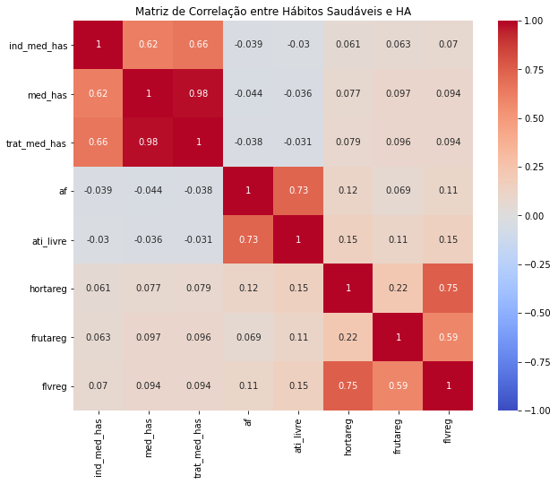

```python
healthy_habits_columns = ['ind_med_has', 'med_has', 'trat_med_has', 'af', 'ati_livre', 'hortareg', 'frutareg', 'flvreg']
healthy_habits_data = dataset2023[healthy_habits_columns]
healthy_habits_correlations = healthy_habits_data.corr()

plt.figure(figsize=(10, 8))
sns.heatmap(healthy_habits_correlations, annot=True, cmap='coolwarm', vmin=-1, vmax=1)
plt.title('Matriz de Correlação entre Hábitos Saudáveis e HA')
plt.show()
```

#### Uso de mídias digitais e sedentarismo

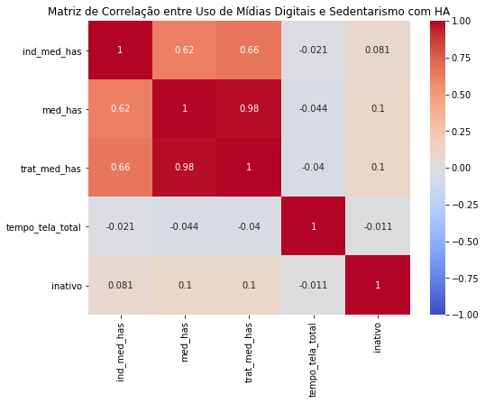

```python
tech_columns = ['ind_med_has', 'med_has', 'trat_med_has', 'tempo_tela_total', 'inativo']
tech_data = dataset2023[tech_columns]
tech_correlations = tech_data.corr()

plt.figure(figsize=(8, 6))
sns.heatmap(tech_correlations, annot=True, cmap='coolwarm', vmin=-1, vmax=1)
plt.title('Matriz de Correlação entre Uso de Mídias Digitais e Sedentarismo com HA')
plt.show()
```

#### A matriz de correlação mostra a relação entre o uso de mídias digitais (tempo de tela) e a inatividade física com os indicadores de hipertensão arterial (HA).

> Sedentarismo: A inatividade física é um fator de risco para HA.

### Machine Learning

Em seguida usaremos um modelo preditivo de Árvore de decisão

O modelo deverá prever a presença de hipertensão arterial com base nos dados comportamentais.

Por exemplo, se o modelo tem uma alta acurácia e bons valores de precisão e recall, isso significa que o modelo é eficaz em identificar indivíduos com hipertensão arterial com base nos fatores comportamentais analisados.

O modelo visa ajudar a identificar padrões e fatores de risco associados à hipertensão arterial, permitindo prever a presença de HA com base em dados comportamentais e demográficos. Isso pode ser útil para iniciativas de saúde pública e intervenções preventivas.

```python
from sklearn.model_selection import train_test_split
from sklearn.tree import DecisionTreeClassifier
from sklearn.metrics import accuracy_score, classification_report

predictive_columns = ['imc', 'obesid', 'fumante', 'exfuma', 'alcabu', 'inativo', 'ind_med_has']

predictive_data = dataset2023[predictive_columns]
predictive_data = predictive_data.dropna()

# Separa variáveis independentes (X) e dependente (y)
X = predictive_data.drop(columns=['ind_med_has'])
y = predictive_data['ind_med_has']

X_train, X_test, y_train, y_test = train_test_split(X, y, test_size=0.3, random_state=42)

clf = DecisionTreeClassifier(random_state=42)
clf.fit(X_train, y_train)

y_pred = clf.predict(X_test)

accuracy = accuracy_score(y_test, y_pred)
report = classification_report(y_test, y_pred)

print(f'Accuracy: {accuracy}')
print(f'Classification Report:\n{report}')
```

```
Accuracy: 0.8766233766233766
Classification Report:
              precision    recall  f1-score   support

         0.0       0.13      0.11      0.12       150
         1.0       0.93      0.94      0.93      1852

    accuracy                           0.88      2002
   macro avg       0.53      0.53      0.53      2002
weighted avg       0.87      0.88      0.87      2002
```

### Desempenho Geral

Acuraca: 0.88 (87.66%) Indica que 87.66% das previsões feitas pelo modelo foram corretas.

Relatório de Classificação Classe 0 (Ausência de HA) Precisão: 0.13 Apenas 13% das previsões da classe 0 estavam corretas. Recall: 0.11 O modelo conseguiu identificar corretamente apenas 11% dos casos reais de ausência de HA. F1-Score: 0.12 Combinação da precisão e recall, indicando desempenho pobre para a classe 0.

Classe 1 (Presença de HA) Precisão: 0.93 93% das previsões da classe 1 estavam corretas. Recall: 0.94 O modelo conseguiu identificar corretamente 94% dos casos reais de presença de HA. F1-Score: 0.93 Excelente desempenho para a classe 1.

Média Macro

Macro Avg: Considera a média das métricas de precisão e recall das duas classes. Precisão: 0.53 Recall: 0.53 F1-Score: 0.53 Média Ponderada

Weighted Avg: Média ponderada das métricas de precisão e recall, levando em conta o número de ocorrências em cada classe.

Precisão: 0.87 Recall: 0.88 F1-Score: 0.87

#### Desempenho Desbalanceado:

O modelo tem um desempenho excelente em prever a presença de HA (classe 1), mas um desempenho muito fraco em prever a ausência de HA (classe 0). Isso indica que os dados podem estar desbalanceados, com muito mais exemplos de HA (classe 1) do que de ausência de HA (classe 0).

#### Impacto do Desbalanceamento:

O desbalanceamento dos dados pode causar o modelo a "ignorar" a classe minoritária (ausência de HA) e focar na classe majoritária (presença de HA), resultando em baixa precisão e recall para a classe minoritária.

### Passos Futuros

- Melhorar o Modelo
- Balanceamento dos Dados:
- Usar técnicas como oversampling (SMOTE) para a classe minoritária ou undersampling para a classe majoritária para equilibrar as classes.
- Ajuste de Hiperparâmetros:
  - Ajustar os hiperparâmetros do modelo de árvore de decisão para melhorar o desempenho.
- Uso de Modelos Avançados:
  - Experimentar com outros modelos como Random Forest, Gradient Boosting ou modelos baseados em redes neurais.
- Validação Cruzada:
  - Usar validação cruzada para garantir que o modelo seja robusto e generalize bem para dados não vistos.